# Objective

## Profitable demographic groups

**Category:** Clustering, Regression  
**Additional Categories:** Neural Networks, Classification

Qmee is a free platform designed with both the brands it works with, and its users, in mind.  
For users, Qmee is a rewarding App that allows you to share your opinions through surveys tailored to you, as well as earn instant cash rewards when shopping and searching online.  
For brands, Qmee is a technology solution that gets better, faster and more accurate answers that can help inﬂuence the direction of your brand.  
One of the services Qmee provides is matching users to research studies (surveys).  
To do that, the company partners with multiple providers who hold surveys about many different topics and wish to ﬁnd users to give an opinion on their brands, products or alike.  
At the same time, users earn a reward every time they complete a study successfully. It is expected for users to have different demographic proﬁles, and the industry assigns different reward amounts for studies depending on multiple factors, one of them being how “on demand” certain proﬁles are.

# What is provided ?

## Qmee data file description

#### transaction_data.csv

| Header | Description |
| --- | --- |
| `user_id` | Unique identifier for the user |
| `income_in_cents` | Amount in cents/pence of the transaction i.e. earning |
| `date_of_transaction` | Date the transaction occurred |
| `currency` | Currency code for the amount |

#### demographics_data.csv

| Header | Description |
| --- | --- |
| `user_id` | Unique identifier for the user |
| `user_profile` | JSON formatted demographic profile for the user |

#### Notes

- The `user_id` in both files match.
- There could be multiple transactions for the same user on the same day.
- JSON profiles need "cleaning up".

The format of the user profile is as follows:

{question_code: {“current_value”: answer_code, “last_updated_at”: updated_date_time, “previous_value": previous_value, “history": [history_values]}, …}

Where

- question_code (numeric) is the code of the question (age, gender, etc).
- answer_code (string) is the code or codes representing the answer for that question (I.e. Gender male). Some questions will accept multiple values (like “hobbies” for example), while others are single values by nature (like age).
- updated_date_time (datetime) is the time of the last update for the current value.
- previous_value (string) is the previous answer to the question if it was updated at some point (or null). If the user didn’t own a car but now it does, the previous value will be the code associated with "does not own a car".
- history_values (string array) are the updates to current_value in the users history. The history logs the date of the change as well as the value of such change.

# What is expected ?

### The goal of this project are, but not limited to:

● Extract/clean the data  
● Determine which data points are important enough to consider during clustering  
● Find the correlation between earnings and demographic blocks, if any  
● Use clustering techniques to determine average earnings for relevant groups  
● Decide which groups have the best acquisition value  
● Expose any other valuable information that could be used to leverage demographic groups

```python
# import all required packages
import numpy as np
import pandas as pd
import json
from pandas.io.json import json_normalize
import matplotlib.pyplot as plt
from sklearn.cluster import KMeans
import pandas_profiling
import matplotlib
# Suppress warnings all subsquent same warning
# A warning is displayed just once
import warnings
```

```python
# confgirue notebook
matplotlib.use('TkAgg')
warnings.filterwarnings(action='once')
# Display a bit more info of user_profile column for further investigation
pd.set_option('display.max_rows', 500)
pd.set_option('display.max_columns', 500)
pd.set_option('max_colwidth', 1000)
%matplotlib inline
```

# Define common functions

```python
def df_replace_null(p_data:pd.DataFrame()):
    return p_data.replace(r'^\s*$', np.nan, regex=True)

def df_replace_string(p_data:pd.Series, p_fromstring:str ='|', p_tostring:str = ',' ):
    return p_data.str.replace(p_fromstring, p_tostring)

def df_split_string(p_data:pd.Series,p_expand = True, p_sep:str =','):
    return p_data.str.split(',',expand=p_expand)

def df_fillna(p_data:pd.DataFrame(), p_fill = '-1'):
    stg_data = p_data.fillna('-1').replace({'None':'-1'})
    return stg_data

def get_unique_counts(p_data:pd.DataFrame(), cat_less_than:int = 15):
    # print value count by columns
    getdummies = {}
    categorize = {}
    all_columns = {}
    for column in p_data.columns:
        # questions_answers[column].str.replace('|',',')
        no_of_columns = df_split_string(p_data[column]).shape[1]
        if no_of_columns == 1:
            unique_count = p_data[column].nunique()
        else:
            unique_count = no_of_columns
        all_columns[column] = unique_count
        if unique_count > cat_less_than or no_of_columns > 1:
            getdummies[column] = unique_count
        else:
            categorize[column] = unique_count
    return all_columns, categorize, getdummies

def plot_question_options(X:list, Y:list, p_title:str) -> None:
    fig = plt.figure(figsize=(30,10))
    fig.suptitle(p_title, fontsize=20, fontweight='bold')
    ax = fig.add_subplot(1,1,1)
    ax.set_title('Number of Questions:{}'.format(len(X)), fontsize=30, fontweight='bold',
                 style='italic',
        bbox={'facecolor': 'red', 'alpha': 0.5, 'pad': 10})
    ax.set_xlabel('Questions', fontsize=20, fontweight='bold')
    ax.set_ylabel('No of Options', fontsize=20, fontweight='bold')
    plt.xticks(rotation=90, fontsize=20, fontweight='bold')
    plt.yticks( fontsize=20, fontweight='bold')
    plt.bar(X,Y)

def df_allcolumns_replace_string(p_data:pd.DataFrame()):
    for column in p_data.columns:
        p_data[column] = df_replace_string(p_data[column])
    return p_data

def df_allcolumns_split_string(p_data:pd.DataFrame()):
    for column in p_data.columns:
        p_data[column] = df_split_string(p_data[column],False)
    return p_data


def plot_bar(p_X:list, p_Y:list, p_title:str,
                 p_width:int = 30, p_height:int = 10,
                 p_xlabel:str = 'Clusters',
                 p_ylable:str = 'Total Earned By Cluster',
                 p_xtick:int = 0
                ) -> None:
    fig = plt.figure(figsize=(p_width,p_height))
    fig.suptitle(p_title, fontsize=20, fontweight='bold',
                 style='italic',
        bbox={'facecolor': 'red', 'alpha': 0.5, 'pad': 10})
    ax = fig.add_subplot(1,1,1)
    ax.set_xlabel(p_xlabel, fontsize=20, fontweight='bold')
    ax.set_ylabel(p_ylable, fontsize=20, fontweight='bold')
    plt.xticks(rotation=90, fontsize=20, fontweight='bold')
    if p_xtick > 0:
         plt.xticks(np.arange(1,p_xtick,1))
    plt.yticks( fontsize=20, fontweight='bold')
    plt.bar(p_X,p_Y)

def plot_cluster(X:list, Y:list, p_title:str) -> None:
    fig = plt.figure(figsize=(30,10))
    fig.suptitle(p_title, fontsize=30, fontweight='bold',
                 style='italic',
        bbox={'facecolor': 'red', 'alpha': 0.5, 'pad': 10})
    ax = fig.add_subplot(1,1,1)
    ax.set_xlabel('Clusters', fontsize=20, fontweight='bold')
    ax.set_ylabel('Total Earned By Cluster', fontsize=20, fontweight='bold')
    plt.xticks(rotation=90, fontsize=20, fontweight='bold')
    plt.xticks(np.arange(1,len(X),1))
    plt.yticks( fontsize=20, fontweight='bold')
    plt.bar(X,Y)
```

# Analyze Transaction File

## Data File: **transactions_data.csv**

### Columns

- date_of_transction: Ignore , as this may not be useful for profiling users
- currency: Ignore if it has a sinlge value
- income_in_cents: Reward earned by a user and it will be useful on determining profitable user group
- user_Id :
  - As per note above, multiple transactions by user id are expected
  - Aggregate tranaction data to calculate sum, average, min and max of income_in_cents by user_id #### Data Processing / Feature Selection
- Create a dataframe from the file
- Count number of total records
- Create a new dataframe with following columns
  - user_id : user_id
  - sum_income : sum(income_in_cents)
  - avg_income : avg(income_in_cents)
  - min_income : min(income_in_cents)
  - max_income : max(income_in_cents)

```python
# Analyze Transaction File, collect stats by unique user ID
# Get MIN , SUM, MEAN, MAX incomes by user and number of transactions
def analyze_trans_file(p_filename: str,
                       p_sep: str=';',
                      p_returntype: str ='PROCESSED' ):
    trans_data = pd.read_csv(p_filename,p_sep)
    # get number of records in original file
    noofrecords = len(trans_data)
    noofunique_userid = trans_data.user_id.nunique()
    noofunique_currency = trans_data.currency.nunique()
    if p_returntype == 'ORIGINAL':
        return noofrecords, noofunique_userid, noofunique_currency, trans_data
    new_trans_data =  trans_data.groupby('user_id').agg(
            min_income=("income_in_cents",'min'),
            sum_income=("income_in_cents",'sum'),
            mean_income=("income_in_cents",'mean'),
            max_income=("income_in_cents",'max'),
            noof_trans=('user_id','count')).reset_index()
    new_trans_data.mean_income = new_trans_data.mean_income.astype('int32')
    unique_mean_income = new_trans_data.mean_income.value_counts()
    print('Transctions:{}, \nUnique UserId:{}, \nUnique Currency:{}, \
              \nRecords in New Data Frame:{}'.format(
            noofrecords, noofunique_userid, noofunique_currency, len(new_trans_data)))
    return noofrecords, noofunique_userid, noofunique_currency, new_trans_data, unique_mean_income
```

```python
# Process transction file
(transactions, unique_userids, unique_currency , trans_data , unique_mean_income) = \
analyze_trans_file('data/transaction_data.csv',';')
```

```
Transctions:548863,
Unique UserId:54899,
Unique Currency:1,
Records in New Data Frame:54899
```

### Following plot to demonstrate potential average income by using the service

### Our objective is to cluster user profiles in higher income group

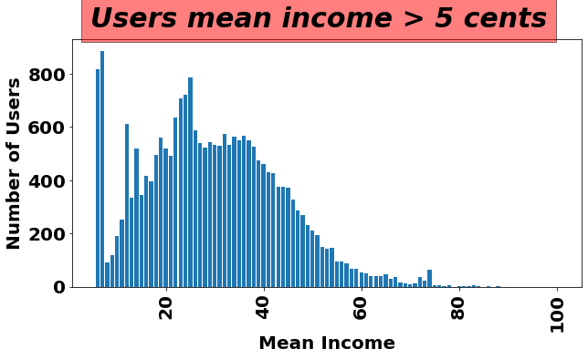

```python
plot_bar(list(unique_mean_income[unique_mean_income.index > 5].index) ,
         list(unique_mean_income[unique_mean_income.index > 5].values),
         'Users mean income > 5 cents',10,5,'Mean Income','Number of Users')
```

# Analyze Demographics File

## Data File: **demographics_data.csv**

### Columns

- user_Id :
  - Single row per user id, not expecting duplicate user_id's
- user_profile :
  - JSON formatted demographic profile for the user and contains following keys
    - Question Code : each question has following keys i.e. 98485098, 102574850
      - Current Value : Answer Code i.e. b02b_38 , a9f8_7a,a9f8_7b,a9f8_68,a9f8_72,a9f8_75
        - May containt multiple answers ranging from 0 to 800+
        - May contain null / white space
        - May contain NaN
        - Multiple answers are separated by either , or |
        - Answer codes by question code are unique
        - An answer belongs to A question only
        - A question may have multiple answers
        - Question : Does answers have different weghts , if so , how to determine ?
      - Last Updated at : Last Update Date and Time i.e 2020-02-05 01:18:06
        - Not used for analysis
      - Previous Value : Previuosly held value i.e. null or
        - Not used for analysis
      - History : Logs change history by date time and value changed to
        - Not used for analysis

#### Data Processing / Feature Selection

```python
def analyze_demg_file(p_filename: str,
                       p_sep: str=';',
                      p_returntype: str ='PROCESSED' ):
    demg_data = pd.read_csv(p_filename,p_sep)
    # get number of records in original file
    noofrecords = len(demg_data)
    noofunique_userid = demg_data.user_id.nunique()
    print('No of Questions:{}'.format(noofquestions))
    if p_returntype == 'ORIGINAL':
        return noofrecords, noofunique_userid, demg_data
    # flattened data
    flattened_data  = pd.json_normalize(demg_data.user_profile.apply(json.loads).values.tolist() )
    # keep only current_value columns i.e. answers
    keep_columns = [x for x in flattened_data.columns if 'current_value' in x]
    # sorten the column names for easy reference
    keep_renamed_columns = {x:x.replace('current_value','a.') for x in flattened_data.columns if 'current_value' in x}
    # creates new data frame only with columns to keep
    questions_data = flattened_data[keep_columns]
    # renames columns
    questions_data.rename(columns=keep_renamed_columns, inplace=True)

    # splits all
    questions_data = demg_data.user_profile.apply(json.loads).apply(pd.Series)
    questions = questions_data.columns
    noofquestions = len(questions)
    questions_answers = questions_answers.fillna('-1')
    for column in questions_answers.columns:
        questions_answers[column] = questions_answers[column].str.replace('|',',')
    new_trans_data.mean_income = new_trans_data.mean_income.astype('int32')
    print('Transctions:{}, \nUnique UserId:{}, \nUnique Currency:{}, \
              \nRecords in New Data Frame:{}'.format(
            noofrecords, noofunique_userid, noofunique_currency, len(new_trans_data)))
    return noofrecords, noofunique_userid, noofunique_currency, new_trans_data
```

```python
demographic_data = pd.read_csv('data/demographics_data.csv', sep=';')
dem_sample = demographic_data
```

```python
# set this option to display full text of user profile to have a better understanding the content
pd.set_option('display.max_colwidth', None)
demographic_data.user_profile.head(1)
```

```
0    {"98485098":{"current_value":"b02b_38","last_updated_at":"2020-02-05 01:18:06"},"102574850":{"current_value":"f902_3b","last_updated_at":"2020-02-05 01:18:06"},"50995553":{"current_value":"2c75_39","last_updated_at":"2020-02-05 01:18:06"},"545310149":{"current_value":"65e1_38-11","last_updated_…
Name: user_profile, dtype: object
```

```python
# level 1 : create columns for each question
questions_data = dem_sample.user_profile.apply(json.loads).apply(pd.Series)
# Capture all questions
no_of_questions = len(questions_data.columns)
print('Number of Questions:{}'.format(no_of_questions))
#
no_of_users = len(questions_data)
print('Number of Users:{}'.format(no_of_users))
# Get count of NaN Rows by columns
nan_rows_by_question = pd.DataFrame(questions_data.isna().sum()).reset_index();
```

```
Number of Questions:87
Number of Users:66937
```

```python
# get Number of Nan Rows
# Can we ignore questions with more than 70% NaN Rows
nan_rows_by_question.columns = ['question','nan_count']
nan_rows_by_question['nan_ratio'] =  ((nan_rows_by_question.nan_count/no_of_users)*100).astype('int16')
```

```python
# nan_rows_by_question.sort_values('nan_ratio', ascending=False)
nan_zero = list(nan_rows_by_question[nan_rows_by_question.nan_ratio == 0].question )
print('Questions with Zero Percent NaN Rows:{}'.format(nan_zero))
nan_75percent = list(nan_rows_by_question[nan_rows_by_question.nan_ratio >75].question )
print('Questions with more than 75 Percent Nan Rows :{}'.format(nan_75percent))
```

```
Questions with Zero Percent NaN Rows:['98485098', '102574850', '50995553', '545310149', '515210149', '545753102', '995755102', '1005210149', '491025299', '56979798', '975557100', '51555699', '555210250', '102555354', '1001015298']
Questions with more than 75 Percent Nan Rows :['501009950', '489810097', '50535753', '51575652']
```

```python
def df_extract_questions(p_data:pd.DataFrame()):
    # Flattens all questions by JSON KEY Value pair
    # Creates a column by question by key  and rows with values
    flattened_data  = pd.json_normalize(p_data.user_profile.apply(json.loads).values.tolist() )
    # yes
    # Keep only <question>.current_value columns
    keep_columns = [x for x in flattened_data.columns if 'current_value' in x]
    keep_renamed_columns = {x:'q'+x.replace('.current_value','') for x in flattened_data.columns if 'current_value' in x}
    # Create a new df only for columns with questions and answers i.e. current_value columns
    current_value_columns = flattened_data[keep_columns]
    current_value_columns.rename(columns=keep_renamed_columns, inplace=True)
    return keep_columns, keep_renamed_columns, current_value_columns

keep_columns, keep_renamed_columns, questions= df_extract_questions(dem_sample)
```

```python
questions
```

|  | q98485098 | q102574850 | q50995553 | q545310149 | q515210149 | q99575553 | q975710256 | q545753102 | q995755102 | q1005210149 | q491025299 | q56979798 | q975557100 | q51555699 | q555210250 | q102555354 | q48525251 | q54575053 | q1001015298 | q5297102102 | q485710150 | q102515456 | q549910252 | q99575648 | q51989754 | q101555754 | q555410155 | q101575053 | q48514955 | … |
| --- | --- | --- | --- | --- | --- | --- | --- | --- | --- | --- | --- | --- | --- | --- | --- | --- | --- | --- | --- | --- | --- | --- | --- | --- | --- | --- | --- | --- | --- | --- |
| 0 | b02b_38 | f902_3b | 2c75_39 | 65e1_38-11 | m-2003-12 | c975_44 | a9f8_7c,a9f8_6b,a9f8_6f,a9f8_7a,a9f8_7b,a9f8_68,a9f8_72,a9f8_75,a9f8_78 | 695f_38-0 | c97f_39-2 | d4e1_3a-3 | 1f4c_3a | 8aab_38 | true | true | false | f756_43 | 0443_37 |  | de4b_38 | 4aff_3b | NaN | NaN | NaN | NaN | NaN | NaN | NaN | NaN | NaN | … |
| 1 | b02b_37 | f902_3d | 2c75_3b | 65e1_38-0 |  | c975_48 | a9f8_79 | 695f_38-6 | c97f_39-2 | d4e1_3a-0 | 1f4c_3c | 8aab_38 | false | true | false | f756_43 | 0443_3a |  | de4b_37 | NaN | 09e2_39 | f368_39 |  |  | 3ba6_37 | e796_41 | 76e7_37 |  | 0317_39 | … |
| 2 | b02b_38 | f902_3c | 2c75_37 | 65e1_38-0 |  | c975_48 |  | None | c97f_39-2 | d4e1_3a-4 | 1f4c_3c | 8aab_3a | false | false | false | f756_46 | 0443_3a | None | de4b_38 |  | 09e2_38 | f368_38 |  |  | 3ba6_3d | e796_42 | NaN |  | 0317_37 | … |
| 3 | b02b_37 | f902_3d | 2c75_3b | 65e1_38-0 |  | c975_44 | NaN | 695f_38-0 | c97f_39-2 | d4e1_3a-0 | 1f4c_3a | 8aab_3a | false | false | true | f756_46 | 0443_3a |  | de4b_38 |  | NaN | NaN |  | NaN | NaN | e796_42 | NaN | e925_3b | 0317_39 | … |
| 4 | b02b_38 | f902_3d | 2c75_37 | 65e1_38-12 |  | c975_44 | a9f8_6c,a9f8_71,a9f8_77,a9f8_7a,a9f8_72,a9f8_79,a9f8_78 | 695f_38-0 | c97f_3a-0 | d4e1_3b-5 | 1f4c_3c | 8aab_39 | true | true | true | f756_43 | NaN | NaN | de4b_38 | NaN | NaN | NaN | NaN | c980_3b,c980_39,c980_38,c980_40,c980_41 | 3ba6_38 | e796_41 | 76e7_38 | e925_39 | 0317_38 | … |
| ... | ... | ... | ... | ... | ... | ... | ... | ... | ... | ... | ... | ... | ... | ... | ... | ... | ... | ... | ... | ... | ... | ... | ... | ... | ... | ... | ... | ... | ... | … |
| 66932 | b02b_38 | f902_3b | 2c75_37 | 65e1_38-21 | m-2020-02\|m-2000-06 | c975_46 | a9f8_7c,a9f8_68,a9f8_72,a9f8_75,a9f8_78 | 695f_38-0 | c97f_3a-0 | d4e1_3b-6 | 1f4c_3b | 8aab_39 | true | false | true | f756_46 | NaN | NaN | de4b_38 | 4aff_3b | NaN | NaN | NaN | NaN | NaN | NaN | NaN | NaN | NaN | … |
| 66933 | b02b_38 | f902_3e | 2c75_37 | 65e1_38-19 | f-2009-08\|f-2017-03\|m-2001-08\|m-2005-12\|u-2017-12 | c975_48 | a9f8_7c,a9f8_6b,a9f8_6f,a9f8_7a,a9f8_7b,a9f8_68,a9f8_72,a9f8_75,a9f8_78 | 695f_38-6 | c97f_3a-2 | d4e1_3a-6 | 1f4c_3a | 8aab_38 | true | true | false | f756_46 | NaN | NaN | de4b_38 | 4aff_37,4aff_3b | NaN | NaN | NaN | NaN | NaN | NaN | NaN | NaN | NaN | … |
| 66934 | b02b_38 | f902_3b | 2c75_37 | 65e1_38-11 | m-2000-04\|m-2001-12\|m-2003-10\|m-2009-06\|f-2016-10 | c975_48 | a9f8_7c,a9f8_6b,a9f8_6f,a9f8_7a,a9f8_7b,a9f8_68,a9f8_72,a9f8_75,a9f8_78 | 695f_38-0 | c97f_3a-2 | d4e1_3a-5 | 1f4c_3a | 8aab_39 | true | true | false | f756_46 | NaN | NaN | de4b_38 | 4aff_3b,4aff_38,4aff_39,4aff_3a,4aff_3c,4aff_3d,4aff_3e,4aff_3f | NaN | NaN | NaN | NaN | NaN | NaN | NaN | NaN | NaN | … |
| 66935 | b02b_38 | f902_3b | 2c75_39 | 65e1_38-7 | m-2006-01 | c975_45 | a9f8_7c,a9f8_6b,a9f8_6f,a9f8_7a,a9f8_7b,a9f8_68,a9f8_72,a9f8_75,a9f8_78 | 695f_38-0 | c97f_3a-2 | d4e1_3a-2 | 1f4c_3a | 8aab_38 | false | false | true | f756_51 | 0443_38 | 6925_39,6925_43,6925_44,6925_46,6925_4e,6925_50,6925_52,6925_4f,6925_55,6925_5b,6925_5c,6925_5d,6925_60,6925_63,6925_68,6925_6b,6925_6f,6925_76,6925_7a,6925_7e,6925_80,6925_81,6925_8d,6925_8f,6925_93,… | de4b_38 | 4aff_3b | NaN | NaN | NaN | NaN | NaN | NaN | NaN | NaN | NaN | … |
| 66936 | b02b_38 | f902_3d | 2c75_3a | 65e1_38-3 |  | c975_44 | a9f8_7c,a9f8_6b,a9f8_6f,a9f8_7a,a9f8_7b,a9f8_68,a9f8_72,a9f8_75,a9f8_78 | 695f_38-4 | c97f_3a-2 | d4e1_3a-1 | 1f4c_3a | 8aab_38 | true | true | false | f756_46 | NaN | NaN | de4b_38 | 4aff_37,4aff_3b | NaN | NaN | NaN | NaN | NaN | NaN | NaN | NaN | NaN | … |

66937 rows × 87 columns

```python
questions  = df_replace_null(questions)
questions = df_fillna(questions)
questions = df_allcolumns_replace_string(questions)
all_columns, categorize, getdummies = get_unique_counts(questions)
```

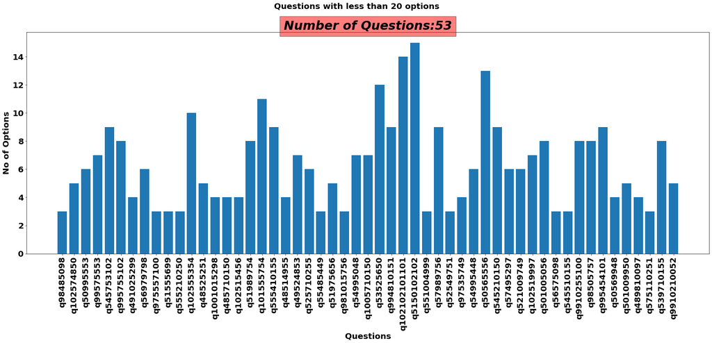

[figure not shown]

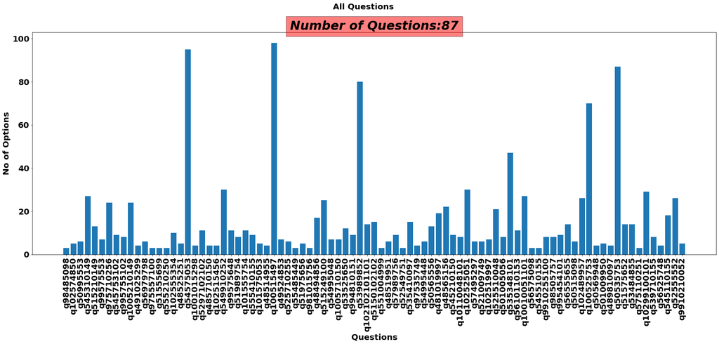

```python
plot_question_options(list(categorize.keys()),list(categorize.values()),'Questions with less than 20 options')
plot_question_options(list(getdummies.keys()),list(getdummies.values()),'Questions with more than 20 options')
plot_question_options(list(all_columns.keys()),list(all_columns.values()),'All Questions')
```

```python
from sklearn.preprocessing import MultiLabelBinarizer
def df_getdummies(p_data:pd.DataFrame()):
    ctr = 0
    x = pd.DataFrame()
    abc = None
    noofanswers = 0
    for column in p_data.columns:
        #ab = pd.get_dummies(p_data[column].apply(pd.Series).stack()).sum(level=0)
        mlb = MultiLabelBinarizer()
        expandedLabelData = mlb.fit_transform(questions[column].str.split(','))
        labelClasses = mlb.classes_
        if len(labelClasses) <= 100:
            # Create a pandas.DataFrame from our output
            ab = pd.DataFrame(expandedLabelData, columns=labelClasses)
            ab.columns = [column+'.'+x for x in ab.columns]
            columns_to_keep = [x for x in ab.columns if '.-1' not in x ]
            print('Question:{}, Answers:{}'.format(column, len(columns_to_keep)))
            noofanswers += len(columns_to_keep)
            if ctr == 0:
                abc =  ab[columns_to_keep]
            else:
                abc[columns_to_keep] = ab[columns_to_keep]
            ctr += 1
    print('No of questions:{}, NoofTotalAnswers:{}'.format(ctr, noofanswers))
    return abc
final_df = df_getdummies(questions)
```

```
Question:q98485098, Answers:2
Question:q102574850, Answers:4
Question:q50995553, Answers:5
Question:q545310149, Answers:26
Question:q99575553, Answers:6
Question:q975710256, Answers:24
Question:q545753102, Answers:8
Question:q995755102, Answers:7
Question:q1005210149, Answers:23
Question:q491025299, Answers:3
Question:q56979798, Answers:5
Question:q975557100, Answers:2
Question:q51555699, Answers:2
Question:q555210250, Answers:2
Question:q102555354, Answers:9
Question:q48525251, Answers:4
Question:q54575053, Answers:95
Question:q1001015298, Answers:3
Question:q5297102102, Answers:11
Question:q485710150, Answers:3
Question:q102515456, Answers:3
Question:q549910252, Answers:30
Question:q99575648, Answers:11
Question:q51989754, Answers:7
Question:q101555754, Answers:10
Question:q555410155, Answers:8
Question:q101575053, Answers:5
Question:q48514955, Answers:3
Question:q100515497, Answers:98
Question:q49524853, Answers:6
Question:q525710255, Answers:5
Question:q55485449, Answers:2
Question:q51975656, Answers:4
Question:q981015756, Answers:2
Question:q48494856, Answers:17
Question:q515249100, Answers:25
Question:q54995048, Answers:6
Question:q1005710150, Answers:6
Question:q53525650, Answers:11
Question:q994810151, Answers:8
```

[output cut: 32 more lines]

```
Question:q100525753, Answers:70
Question:q50569948, Answers:3
Question:q501009950, Answers:4
Question:q489810097, Answers:3
Question:q50535753, Answers:87
Question:q51575652, Answers:14
Question:q53484855, Answers:14
Question:q575110251, Answers:2
Question:q10299100101, Answers:28
Question:q539710155, Answers:7
Question:q56525748, Answers:4
Question:q545110155, Answers:18
Question:q52555552, Answers:26
Question:q9910210052, Answers:4
No of questions:86, NoofTotalAnswers:1241
```

```python
## import sklearn.model_selection as model_selection
##  X_train, X_test = model_selection.train_test_split(final_df, train_size=0.65,test_size=0.35, random_state=101)
```

```python
def get_best_kmeans(p_data:pd.DataFrame(), no_of_clusters:int = 30):
    inertia = []
    for i in range(1,no_of_clusters):
        kmeans = KMeans(n_clusters=i, init='k-means++',
                       max_iter=300, n_init=10, random_state=0)
        kmeans.fit(p_data)
        inertia.append(kmeans.inertia_)
    return inertia
```

```python
inertia_1_30 = get_best_kmeans(final_df)
```

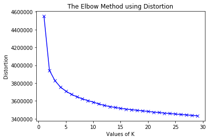

```python
plt.plot(range(1,30), inertia_1_30, 'bx-')
plt.xlabel('Values of K')
plt.ylabel('Distortion')
plt.title('The Elbow Method using Distortion')
plt.show()
```

```python
def run_kmeans(p_cluster:int = 15):
    wcss = []
    kmeans = KMeans(n_clusters=p_cluster, init='k-means++',
                       max_iter=100, n_init=10, random_state=0)
    kmeans.fit_predict(final_df)
    return kmeans.labels_
```

```python
## Start from here *********************************************
clusters = run_kmeans(10)
```

```python
# Add UserID and Cluser Number to feature engineered dataframe
## Aggregate Min / Max / Sum / Counts of by Cluser Number
def get_merged_df(p_data:pd.DataFrame, p_cluster):
    stg_df = p_data
    stg_df['cluster'] = p_cluster
    stg_df['user_id'] = dem_sample['user_id']
    merged_df = pd.merge(trans_data,stg_df, on='user_id')
    returned_columns = [x for x in merged_df.columns if 'q' not in x]
    user_in_cluster = merged_df[returned_columns]
    print(user_in_cluster.columns)
    agg_by_cluster =   user_in_cluster.groupby('cluster').agg(
            min_income=("min_income",'min'),
            sum_income=("sum_income",'sum'),
            mean_income=("mean_income",'mean'),
            max_income=("max_income",'max'),
            noof_trans=("cluster",'count')).reset_index()
    return user_in_cluster, agg_by_cluster
```

```python
user_in_cluster , agg_by_cluster = get_merged_df(final_df,clusters)
```

```
Index(['user_id', 'min_income', 'sum_income', 'mean_income', 'max_income',
       'noof_trans', 'cluster'],
      dtype='object')
```

```python
agg_by_cluster['income_per_trans'] = (agg_by_cluster.sum_income/agg_by_cluster.noof_trans).astype(int)
```

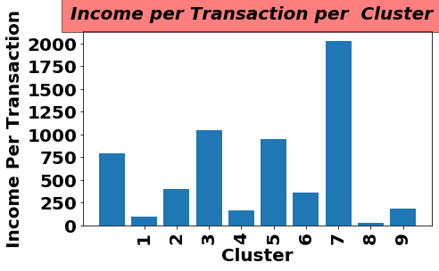

```python
# Some more analysis
plot_bar(list(agg_by_cluster.cluster) ,
         list((agg_by_cluster.sum_income/agg_by_cluster.noof_trans)),
         'Income per Transaction per  Cluster',7,4,'Cluster','Income Per Transaction',len(agg_by_cluster))
```

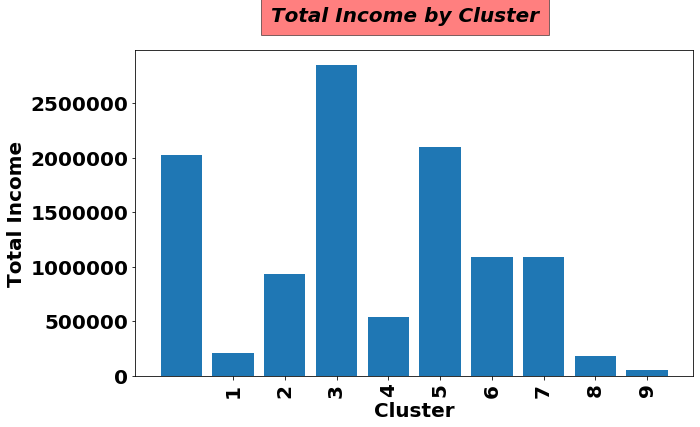

```python
plot_bar(list(cluster_sumincome_sorted.cluster) ,
         list(cluster_sumincome_sorted.sum_income),
         'Total Income by Cluster',10,6,'Cluster','Total Income',len(agg_by_cluster))
```

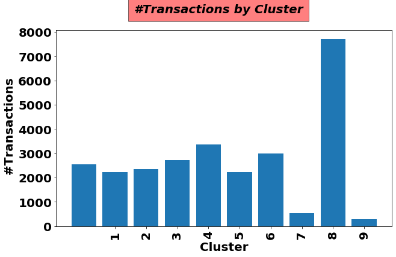

```python
plot_bar(list(agg_by_cluster.cluster) ,
         list(agg_by_cluster.noof_trans),
         '#Transactions by Cluster',10,6,'Cluster',' #Transactions',len(agg_by_cluster))
```

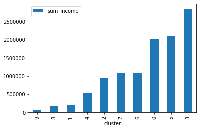

```python
cluster_sumincome_sorted = agg_by_cluster.sort_values('sum_income')
# Total Income by Cluster
cluster_sumincome_sorted.plot(kind='bar', x='cluster', y='sum_income')
```

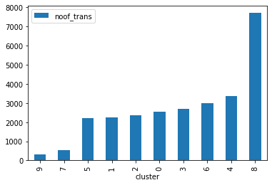

```python
cluster_nooftrans_sorted = agg_by_cluster.sort_values('noof_trans')
# Number of transaction by each cluster
cluster_nooftrans_sorted.plot(kind='bar', x='cluster',y=['noof_trans'])
```

```python
# Assign cluster id to original demographic data
user_profile = demographic_data
user_profile['cluster'] = clusters
```

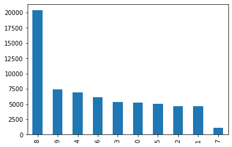

```python
# Number of users in Cluster
user_profile.cluster.value_counts().plot(kind='bar');
```

```python
cluster_incomepertrans_sorted = agg_by_cluster.sort_values('income_per_trans')
```

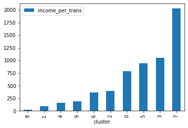

```python
# Income per transaction per cluser
cluster_incomepertrans_sorted.plot(kind='bar', x='cluster', y='income_per_trans')
```

## "On-Demand" profiles are in Cluster 0 , 5 , 3 , 7